| REPUBLIQUE DU SENEGAL |
| --- |

| ********** |
| --- |
| Un Peuple - Un But - Une Foi |
| ********** |
| Agence nationale de la Statistique et de la démographie |

[figure not shown]

| ********** |
| --- |
| Ecole nationale de la Statistique et de l'Analyse économique Pierre Ndiaye |

[figure not shown]

##### Projet statistique sur R : Evaluation

| Rédigé par : | Sous la supervision de : |
| --- | --- |
| RASAMOELINA Nihaviana Albert Paulinah | M. Aboubacar HEMA |
| Élève ISE1 ECO | Research analyst à IFPRI |

| **Année académique 2024-2025** |
| --- |

# *Introduction*

Ce rapport présente une analyse statistique complète réalisée dans le cadre de l’examen de projet statistique sur R pour ISE année 1. L’objectif est d’analyser un ensemble de données relatives liées aux déplacements forcés au Sud-Soudan en 2023. Ce rapport suit les instructions fournies dans le sujet d’examen et comprend une analyse de consistance des données, le calcul d’indicateurs clés, des analyses socio-démographiques et des visualisations spatiales.

[output not shown]

# I. Importation et Analyse de consistance des bases

## 2. Analyse de consistance des bases de données

Cette section vise à vérifier la qualité des données importées et à appliquer les transformations nécessaires pour assurer leur cohérence avant l’analyse. Nous utiliserons principalement les packages `janitor` et `tidyverse` pour cette tâche.

### 2.1. Analyse préliminaire des bases de données

Commençons par examiner les dimensions et les caractéristiques générales de nos bases de données.

```
Dimensions de la base individus: 22092 144
```

```
Dimensions de la base principale: 3058 1312
```

```
Nombre de valeurs manquantes par colonne (top 10) - base individus:
```

```
HH_00b_month  HH_00b_year       HH_11b       Dis_18       Dis_15       Dis_12
       22089        22077        22025        21978        21954        21879
       ID_04        HH_16        ID_06       Dis_06
       21852        21760        21710        21692
```

```
Nombre de valeurs manquantes par colonne (top 10) - base principale:
```

```
HH_31b16 HH_31b17 HH_31b18 HH_31b19 HH_31b20 HH_31b21 HH_31b22 HH_31b23
    3058     3058     3058     3058     3058     3058     3058     3058
HH_31b24 HH_31b25
    3058     3058
```

```
Pourcentage global de valeurs manquantes - Base Ind: 64.64 %
```

```
Pourcentage global de valeurs manquantes - Base Prin: 65.55 %
```

### 2.2 Nettoyage des bases de données avec janitor

Le package `janitor` offre des fonctions utiles pour nettoyer les bases de données. Appliquons quelques-unes de ces fonctions à nos bases.

```
Colonnes presque vides (>90% NA) dans la base Ind: 36
```

```
 [1] "HH_00a_year"  "HH_00a_month" "HH_00b_year"  "HH_00b_month" "HH_11b"
 [6] "ID_04"        "ID_06"        "HH_07b"       "HH_10name16"  "HH_10name17"
```

```
Colonnes presque vides (>90% NA) dans la base Prin: 589
```

```
 [1] "HH_31b1"  "HH_31b2"  "HH_31b3"  "HH_31b4"  "HH_31b5"  "HH_31b6"
 [7] "HH_31b7"  "HH_31b8"  "HH_31b9"  "HH_31b10"
```

```
Lignes presque vides (>90% NA) dans la base Ind: 0
```

```
Lignes presque vides (>90% NA) dans la base Prin: 0
```

[output not shown]

[output not shown]

### 2.3 Suppression des colonnes et lignes inutiles

Sur la base de l’analyse ci-dessus, nous pouvons décider de supprimer certaines colonnes ou lignes qui contiennent principalement des valeurs manquantes. Cependant, il est important de ne pas supprimer des données qui pourraient être pertinentes pour l’analyse.

```
Dimensions de la base Ind avant: 22092 144
```

```
Dimensions de la base Ind après: 22092 116
```

```
Dimensions de la base Prin avant: 3058 1312
```

```
Dimensions de la base Prin après: 3058 873
```

```
Dimensions de la base Ind après suppression des lignes: 22092 116
```

```
Dimensions de la base Prin après suppression des lignes: 3058 873
```

### 2.4. Traitement des doublons

Vérifions s’il existe des doublons dans les bases de données.

```
Nombre de lignes avec des IDs dupliqués dans la base Ind: 2971
```

```
Nombre de lignes dupliquées dans la base Prin: 0
```

### 2.5. Cohérence entre les bases de données

Vérifions la cohérence entre les bases de données Ind et Prin, notamment la correspondance des identifiants.

```
Nombre d'IDs dans Ind qui n'existent pas dans Prin: 0
```

```
Nombre d'IDs dans Prin qui n'existent pas dans Ind: 0
```

### 2.6. Traitement des valeurs aberrantes

Examinons certaines variables numériques clés pour détecter d’éventuelles valeurs aberrantes.

```
Nombre de valeurs aberrantes pour l'âge: 0
```

### 2.7. Standardisation des types de données

S’assurer que les variables ont le type approprié.

[output not shown]

[output cut: 103 more lines]

[output not shown]

### 2.8. Résumé du nettoyage

```
Résumé des modifications apportées:
```

```
1. Colonnes supprimées (>95% NA) - base individus: 28
```

```
2. Colonnes supprimées (>95% NA) - base principale: 439
```

```
3. Lignes supprimées (>95% NA) - base individus: 0
```

```
4. Lignes supprimées (>95% NA) - base principale: 0
```

```
Pourcentage final de valeurs manquantes - base individus: 56.83 %
```

```
Pourcentage final de valeurs manquantes - base principale: 48.97 %
```

### 2.9. Finalisation des bases de données nettoyées

Remplaçons les bases de données originales par les versions nettoyées pour la suite de l’analyse.

[output not shown]

## 3. Exploration des données

### 3.1. Structure des bases de données

Pour mieux comprendre les données, examinons la structure des deux bases et les principales variables disponibles.

```
[1] 22092   116
```

```
[1] 3058  873
```

## 3.2. Variables catégorielles importantes

Examinons les variables catégorielles importantes comme le sexe, le statut marital, etc.

```
  Male Female   <NA>
 10821  11251     20
```

```
       Male      Female        <NA>
48.98153178 50.92793772  0.09053051
```

```
monogamous/married polygamous/married   non-formal union          separated
              5631                660                 43                260
          divorced   widow or widower      never married               <NA>
               157                422               7339               7580
```

```
monogamous/married polygamous/married   non-formal union          separated
        25.4888647          2.9875068          0.1946406          1.1768966
          divorced   widow or widower      never married               <NA>
         0.7106645          1.9101937         33.2201702         34.3110628
```

```
             yes               no       don't know refuse to answer
            7021             7956               12                2
            <NA>
            7101
```

```
             yes               no       don't know refuse to answer
    31.780735108     36.013036393      0.054318305      0.009053051
            <NA>
    32.142857143
```

```
    1     2     3     4     5     6     7     8     9    10    11    12    13
 1213  1098   950   869   641   506   369   370   220   221   180   198     5
   14    15    16    17    18    19    20    21    22    23    24    27    28
    3     9    12     5     4     2     1    10    15     2     1     1    52
   29  <NA>
   40 15095
```

```
           1            2            3            4            5            6
 5.490675358  4.970124932  4.300199167  3.933550607  2.901502806  2.290421872
           7            8            9           10           11           12
 1.670287887  1.674814412  0.995835597  1.000362122  0.814774579  0.896252037
          13           14           15           16           17           18
 0.022632627  0.013579576  0.040738729  0.054318305  0.022632627  0.018106102
          19           20           21           22           23           24
 0.009053051  0.004526525  0.045265254  0.067897882  0.009053051  0.004526525
          27           28           29         <NA>
 0.004526525  0.235379323  0.181061018 68.327901503
```

```
                 Government or Public                             UN or NGO
                                 1328                                  5212
Religious or faith-based organization                             Community
                                  167                                    17
                              Private                        Other: specify
                                  282                                     5
                           Don't know                                  <NA>
                                   10                                 15071
```

```
                 Government or Public                             UN or NGO
                           6.01122578                           23.59225059
Religious or faith-based organization                             Community
                           0.75592975                            0.07695093
                              Private                        Other: specify
                           1.27648017                            0.02263263
                           Don't know                                  <NA>
                           0.04526525                           68.21926489
```

## 3.3. Statistiques descriptives des variables numériques

```
ageYears
    1103
```

```
    ageYears
 Min.   : 1.00
 1st Qu.: 7.00
 Median :15.00
 Mean   :18.55
 3rd Qu.:26.00
 Max.   :60.00
 NA's   :1103
```

# II. Analyse des données socio-démographiques

## 1. Répartition par âge et sexe

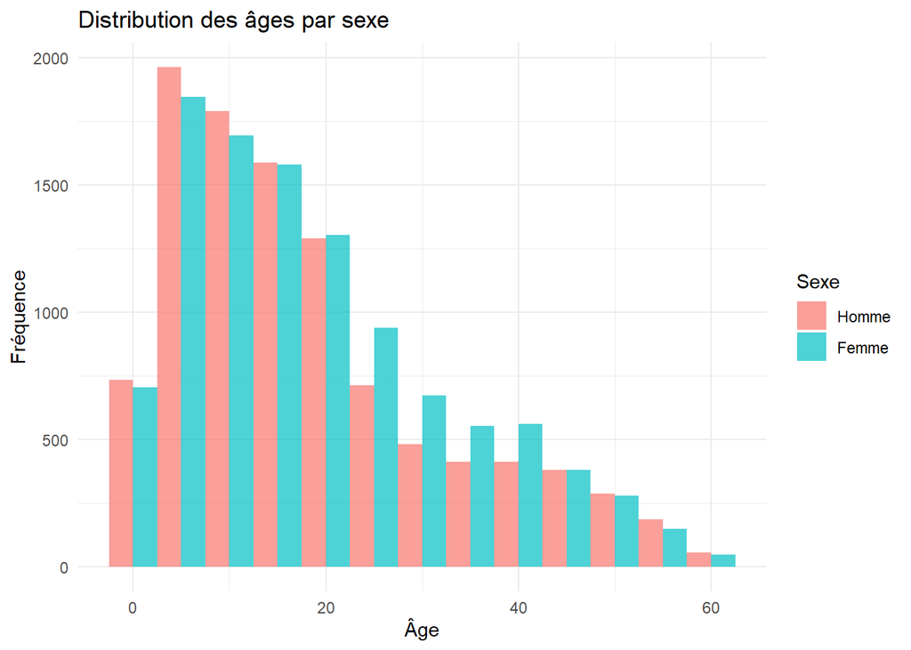

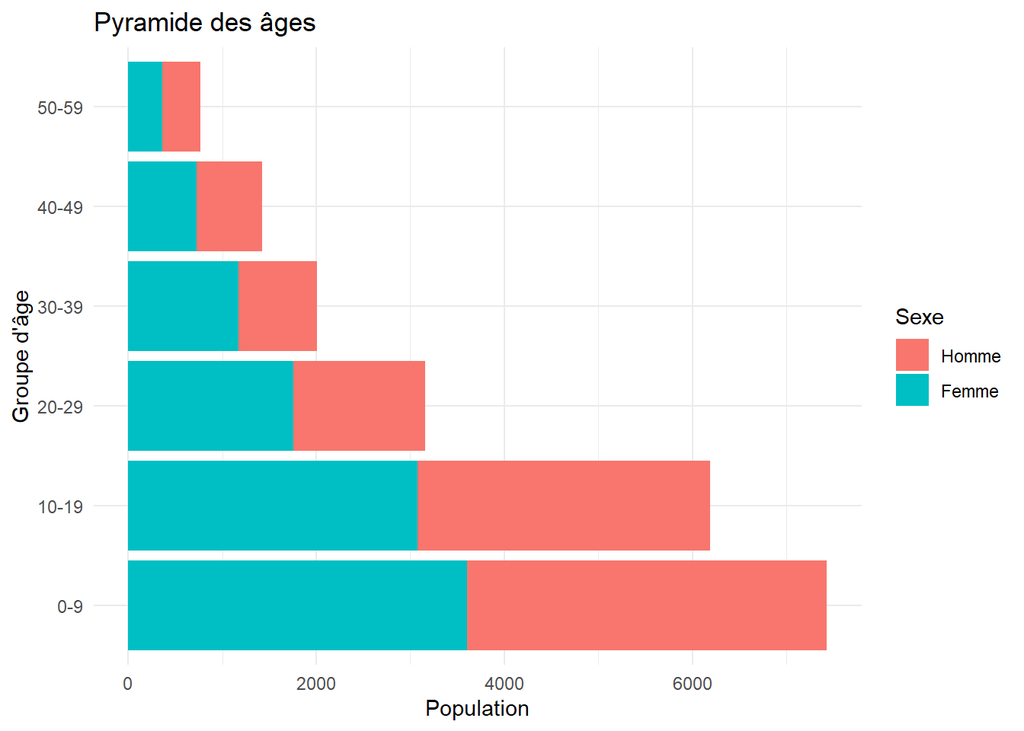

## 2. Analyse du niveau d’éducation

[figure not shown]

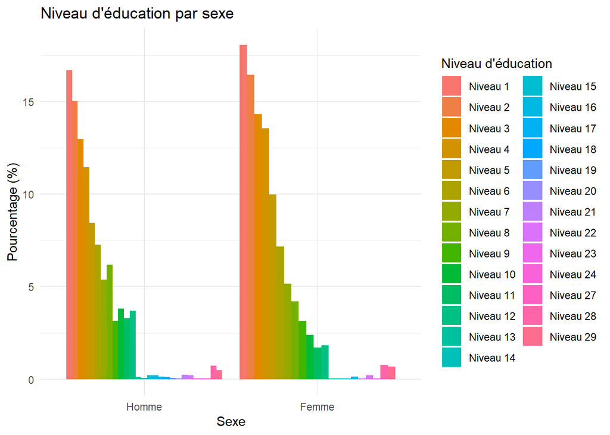

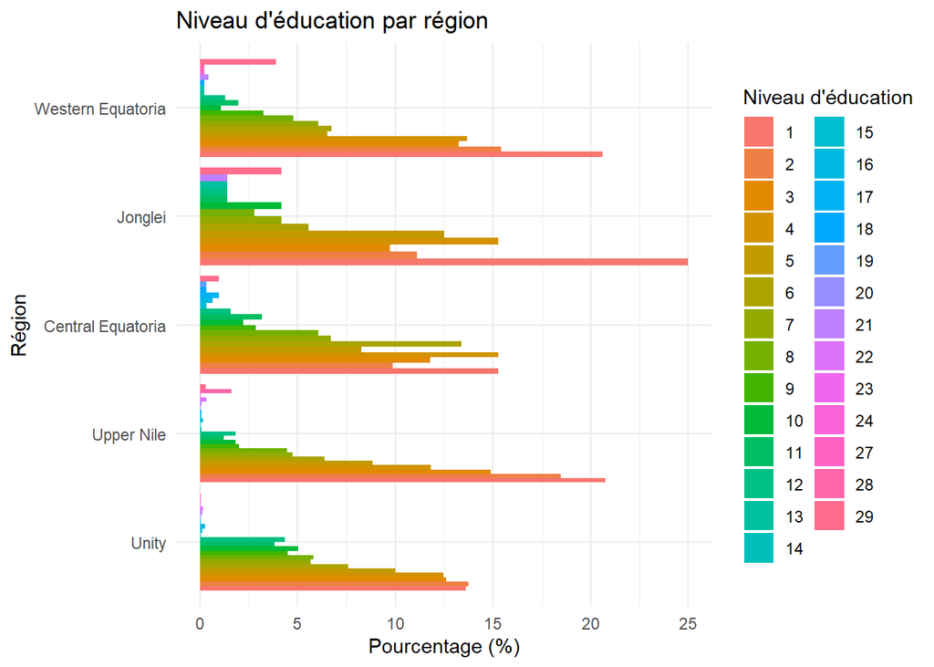

# III Calcul et analyse du Crowding Index (Indice d’affluence)

Le Crowding Index ou indice d’affluence est le rapport entre le nombre de personnes vivant dans un ménage et le nombre de pièces disponibles (à l’exclusion de la cuisine et des couloirs). Cet indice est un indicateur important des conditions de vie des ménages.

## 1. Calcul du nombre d’individus par ménage

```
   Min. 1st Qu.  Median    Mean 3rd Qu.    Max.
  1.000   5.000   7.000   7.224   9.000  17.000
```

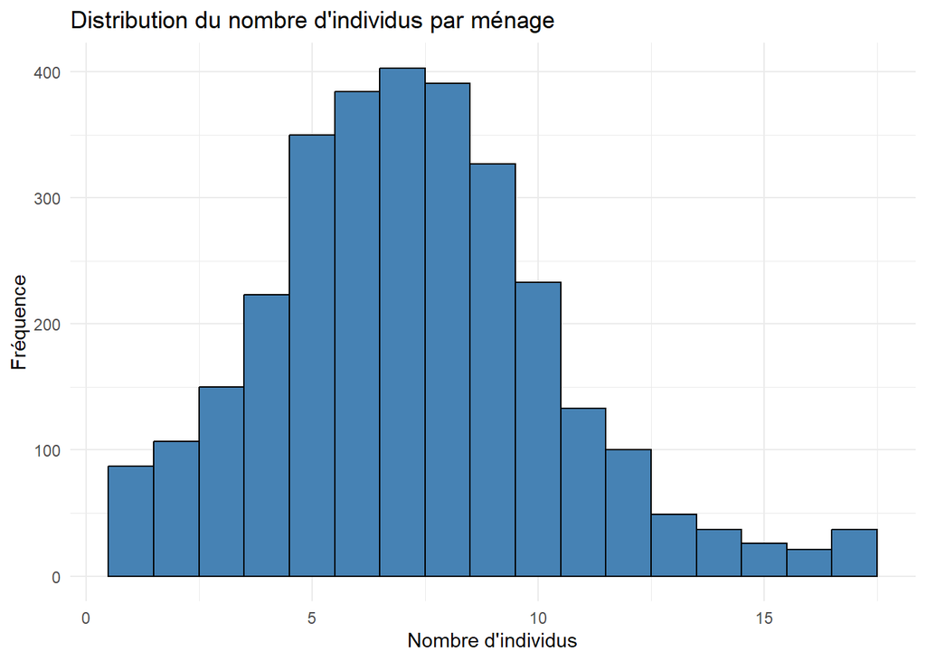

## 2. Statistiques descriptives sur le nombre de pièces

```
   Min. 1st Qu.  Median    Mean 3rd Qu.    Max.    NA's
  1.000   2.000   2.000   2.388   3.000  21.000       6
```

```
Nombre de valeurs non finies exclues : 6
```

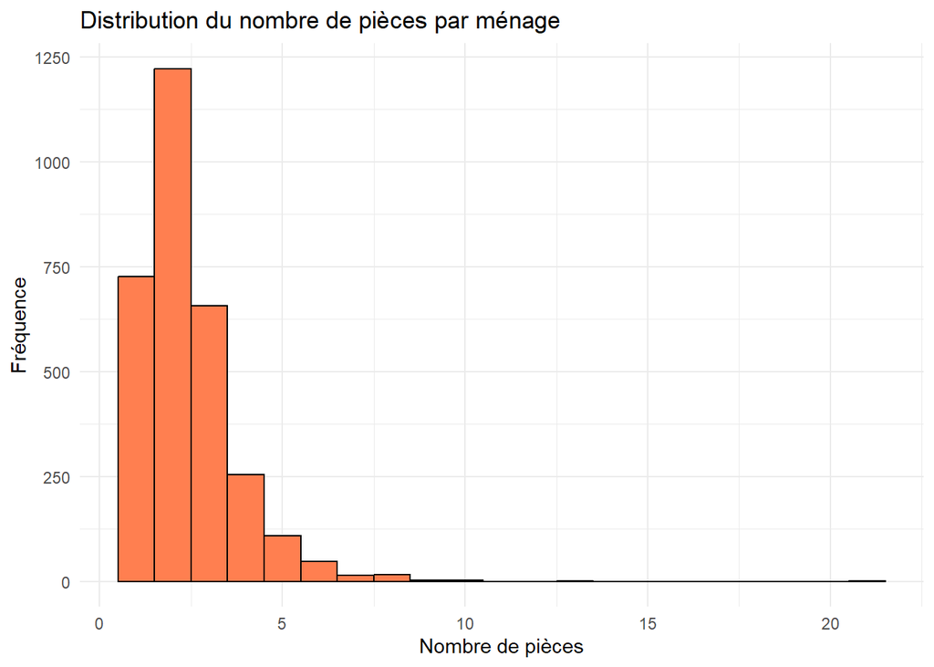

## 3. Calcul de l’indice d’affluence (Crowding Index)

```
   Min. 1st Qu.  Median    Mean 3rd Qu.    Max.    NA's
 0.1905  2.0000  3.0000  3.5997  4.5000 15.0000       6
```

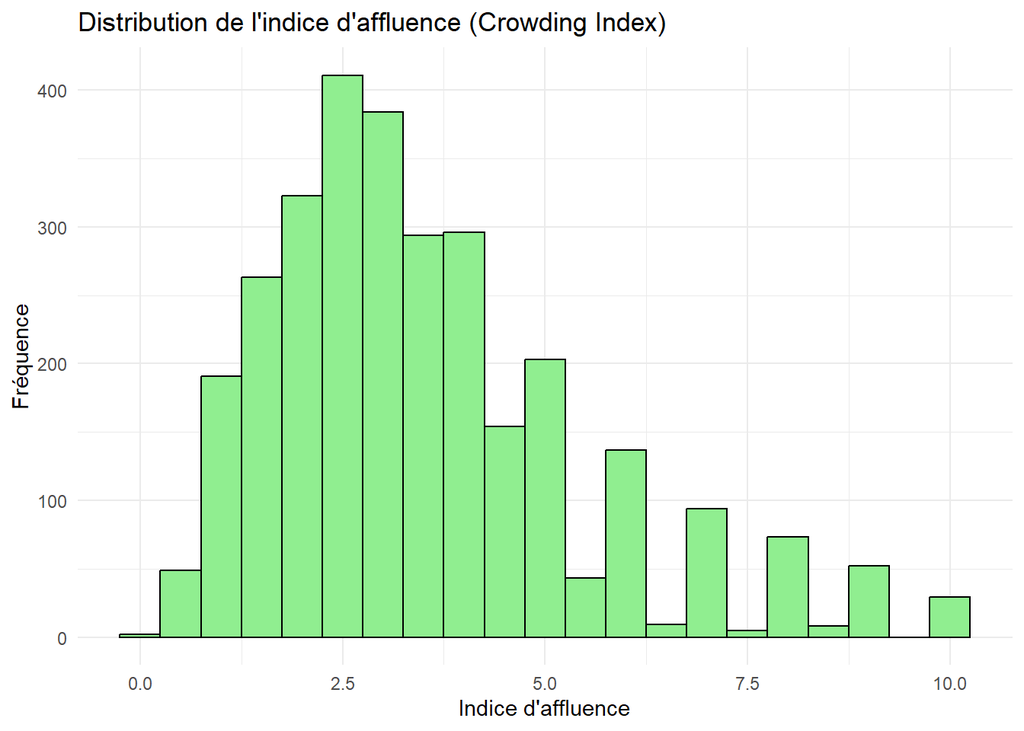

## 4. Analyse de la distribution de l’indice d’affluence

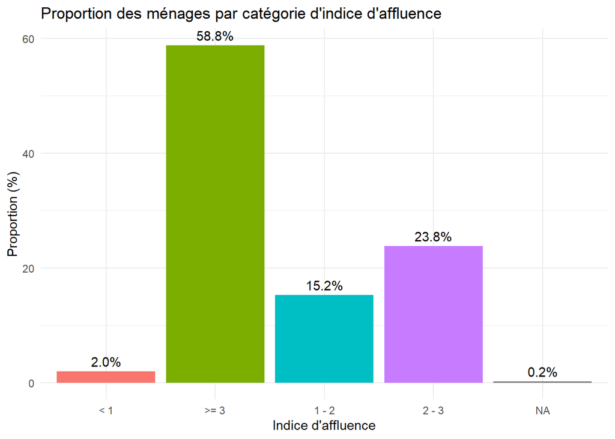

## 5. Comparaison entre réfugiés et communautés d’accueil

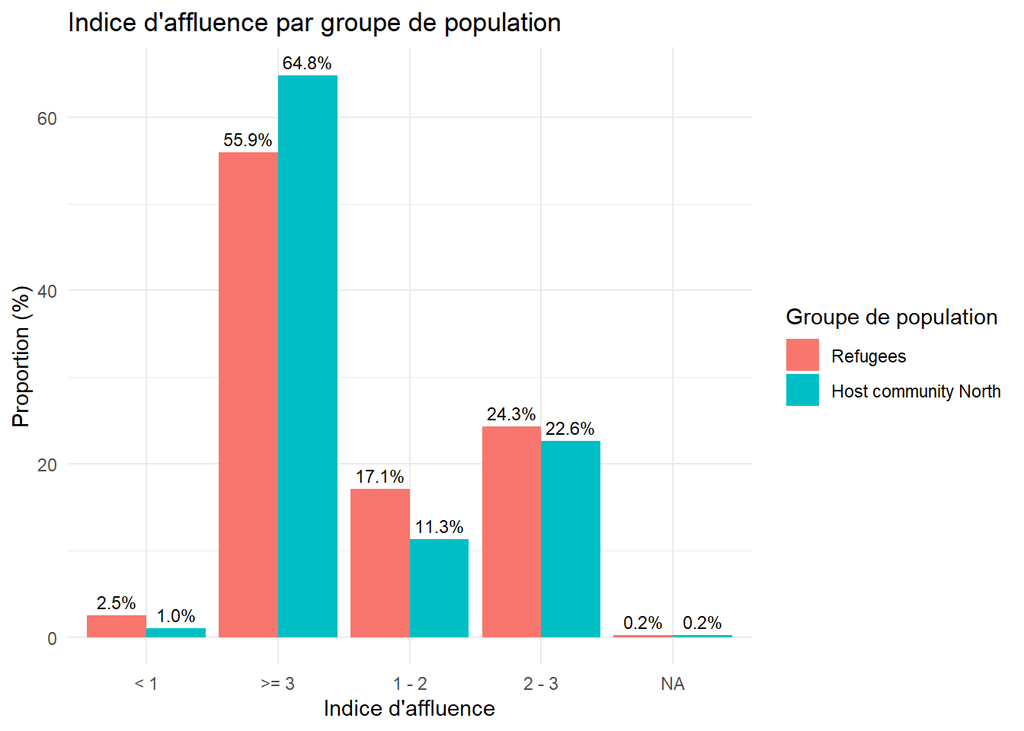

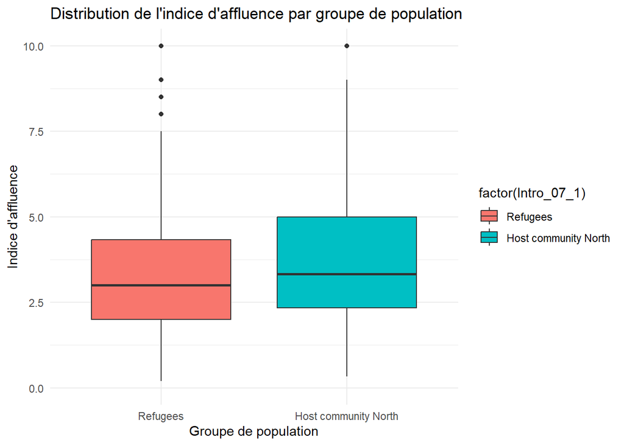